# R Notebook

# Задача 1

Для маркетингового исследования случайным образом необходимо отобрать N людей. Этим людям далее демонстрируется кофе марки Nescafe в упаковке с новым дизайном: вместо классической этикетки в коричнево-золотых тонах – новогодняя этикетка в красно-зеленых тонах. После этого фиксируется,сколько людей захотели купить этот кофе, а точнее, доля таких людей.Рассчитайте необходимый объем выборки для тестовой группы, если известно, что •выбран 95%-ный уровень доверия; •погрешность не должна превышать 3%; •нет определенных ожиданий относительно доли людей, которые захотят кофе с измененнымдизайном этикетки (считается, что человек с равной вероятностью выберет кофе или не выберет) N = z**2*p*(1-p)/(error**2)

```r
library(DescTools)
N = 1.96 ** 2 * 0.5 * 0.5 / (0.03 ** 2)
N
```

```
[1] 1067.111
```

# Задача 2

Решите задачу 1, учитывая, что теперь ожидаемая доля людей, которые захотят купить кофе с измененным дизайном этикетки, известна и равна 0.67 (группа аналитиков нашла старый отчет срезультатами аналогичного эксперимента). Какой из необходимых объемов выборки больше: в случае, когда мы считаем, что шансы выбрать и невыбрать кофе одинаковы или в случае, когда ожидаемая доля выбравших кофе нам известна и равна 0.67? Сделайте вывод о связи между ожидаемой долей и необходимым объемом выборки при прочихравных условиях (тот же уровень доверия).

```r
N2 = 1.96 ** 2 * 0.67 * 0.33 / (0.03 ** 2)
N2
```

```
[1] 943.7531
```

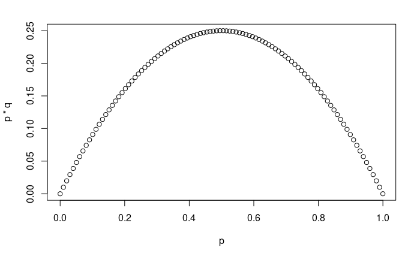

```r
# Обьъем выборки прямо зависит от перемножения p и q, чем меньше произведение, тем меньше объем выборки
p = seq(0,1, length.out = 100)
q = seq(1,0, length.out = 100)
plot(p,p*q)
```

Из графика видно, что наибольший объем выборки нужен при p = q, не помню как это доказывается # Задача 3 В файле experiment.csv сохранены результаты эксперимента, описанного в задаче 1. Данные представляют собой последовательности из 0 и 1, где 1 соответствуют людям, которые захотели выбрать кофе с измененным дизайном этикетки, а 0 - людям, которые не захотели.Описание данных: test: результаты по тестовой группе (людям предлагали кофе с новым дизайном этикетки); control:контрольная группа (людям предлагали кофе со старым дизайном этикетки). 1. Загрузите в R данные из файла experiment.csv с помощью функции read.csv(). 2.Постройте в R 90%-ный доверительный интервал для доли людей, которые захотели купить кофе,в тестовой группе. Проинтерпретируйте полученный доверительный интервал.В решении приведите используемый код, границы доверительного интервала и текст с интерпретацией. 3.Постройте в R 90%-ный доверительный интервал для доли людей, которые захотели купить кофе,в контрольной группе. Проинтерпретируйте полученный доверительный интервал.В решении приведите используемый код, границы доверительного интервала и текст с интерпретацией. 4.Сравните полученные доверительные интервалы для тестовой и контрольной группы. Можно ли на основании полученных результатов сделать определенный вывод о том, что новый дизайн этикетки лучше (привлекает больше потенциальных покупателей)? Приведите ваши выводы иобъяснения. 5.Выполните пункты 1-3 в Python. Изменились ли ваши выводы относительно полезности новогодизайна этикетки? Приведите код, результаты и текст с выводами.

```r
# 1
df <- read.csv("./experiment.csv")
df
```

| X | control | test |
| --- | --- | --- |
| 1 | 0 | 0 |
| 2 | 1 | 1 |
| 3 | 0 | 0 |
| 4 | 0 | 0 |
| 5 | 0 | 0 |
| 6 | 1 | 1 |
| 7 | 1 | 1 |
| 8 | 1 | 0 |
| 9 | 1 | 0 |
| 10 | 1 | 1 |

[output cut: 990 more lines]

```r
NA
```

```r
# 3,2
control.suc <- sum(df$control)
control.interval <- BinomCI(control.suc, length(df$control), conf.level=0.9)
cat("Доверительный интервал для контрольной группы: ", control.interval[2:3], "\n")
```

```
Доверительный интервал для контрольной группы:  0.4381921 0.4900022
```

```r
test.suc <- sum(df$test)
test.interval <- BinomCI(test.suc, length(df$test), conf.level=0.9)
cat("Доверительный интервал для тестовой группы: ", test.interval[2:3])
```

```
Доверительный интервал для тестовой группы:  0.5511289 0.6024556
```

# 4

Могу сказать, что люди более склонны брать кофе в новой упаковке

[output not shown]